# El cambio climático y la gestión oceánica determinan la resiliencia de la biomasa marina en el Corredor Marino del Pacífico Este Tropical

Palacios-Abrantes, J., Clarke, T. M., Jiménez, A. B., Romero-Chaves, R., Villalobos-Rojas, F., Sánchez-Godínez, C., Viteri-Mejía, C., Martínez-Fernández, D., Moity, N., Ramírez, J. y Cheung, W. W.

Octubre, 2026

[figure not shown]

- **NOTA: esta es una traducción al español del artículo:** *Climate change and ocean management shape marine biomass resilience in the Marine Corridor of the Eastern Tropical Pacific*, escrito por Juliano Palacios-Abrantes y colaboradores, publicado en *Discover Oceans* (2026) 3:38. No cuenta con la sección de Agradecimientos, Contribuciones de autoría, ni las figuras y tablas suplementarias originales del artículo.
- **Traducido por Juliano Palacios.**
- **Forma de citar**: Palacios-Abrantes, J., Clarke, T. M., Jiménez, A. B., Romero-Chaves, R., Villalobos-Rojas, F., Sánchez-Godínez, C., Viteri-Mejía, C., Martínez-Fernández, D., Moity, N., Ramírez, J. y Cheung, W. W. (2026). Climate change and ocean management shape marine biomass resilience in the Marine Corridor of the Eastern Tropical Pacific. *Discover Oceans*, 3:38.

Descargar Artículo en Español

## Resumen

El Corredor Marino de Conservación del Pacífico Este Tropical (CMAR) fue establecido en 2004 mediante la cooperación de Colombia, Costa Rica, Ecuador y Panamá, con el objetivo de proteger las rutas migratorias de especies pelágicas de gran tamaño como tiburones, rayas, tortugas y mamíferos marinos. A medida que el cambio climático modifica los ecosistemas marinos a nivel mundial, los recientes y ambiciosos esfuerzos de conservación de CMAR podrían verse afectados por los desplazamientos de rango de especies impulsados por el clima hacia la corriente de Humboldt. En este trabajo, buscamos identificar posibles estrategias de adaptación y manejo para mejorar la resiliencia climática de la biodiversidad y las pesquerías en diez áreas marinas protegidas (AMP) de la región de CMAR. Nos basamos en la construcción de escenarios y en modelos integrados espacialmente explícitos de clima-peces-pesquerías para proyectar los impactos del cambio climático sobre la biomasa marina de especies clave bajo diferentes escenarios de manejo pesquero y protección marina. Nuestros resultados muestran que la biomasa en la región de CMAR, así como la efectividad de las AMP para sostener la conservación de biomasa, la producción de alimentos marinos y el turismo sostenible, se ven fuertemente afectadas por los escenarios de mayores emisiones. Mejorar el manejo pesquero y la conservación podría contrarrestar parte de los impactos del cambio climático, especialmente si se implementan en paralelo. Adaptar los planes de manejo pesquero y de las AMP dentro de la región de CMAR a los desplazamientos de rango impulsados por el clima es esencial para alcanzar sus objetivos de conservación establecidos. Mejorar nuestra comprensión de los impactos del cambio climático sobre la biodiversidad marina y la biomasa de especies clave de importancia comercial puede aumentar la efectividad de los planes de conservación y manejo pesquero para construir resiliencia climática de los ecosistemas en la región.

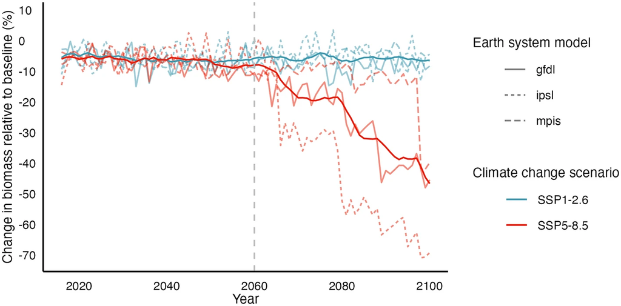

**Cambios en la biomasa de especies clave en la región de CMAR bajo el cambio climático. Las líneas de colores sólidos representan el promedio móvil de cinco años de los tres Modelos del Sistema Tierra (ESM), mientras que las líneas atenuadas representan las trayectorias de cada ESM (Imagen original, Palacios-Abrantes et al. 2026, Figure 1)**

## 1. Introducción

El cambio climático está provocando la redistribución global de las especies marinas, con impactos en la biodiversidad que repercuten en las comunidades y los ecosistemas [1]. La transformación del ambiente oceánico obliga a las especies a desplazar sus distribuciones en busca de las condiciones ambientales a las que están adaptadas [2]. Estos desplazamientos están provocando desajustes entre las áreas marinas protegidas (AMP) y la distribución de los objetivos de conservación, lo que amenaza la efectividad de los esfuerzos globales por ampliar la protección marina. Este desafío probablemente se intensificará en los próximos años, a medida que las condiciones ambientales cambien dentro de las AMP [3], con impactos sobre la biodiversidad y la biomasa de peces [4]. En este artículo, exploramos las consecuencias del cambio climático sobre la conservación y el manejo de especies clave en una red de AMP transfronterizas en el Pacífico Este Tropical (ETP). Exploramos opciones de manejo y discutimos formas en que las redes regionales de AMP pueden adaptarse y mitigar los impactos del cambio climático.

El ETP se extiende desde el Golfo de California (México) hasta el norte de Perú, una región caracterizada por altos niveles de endemismo y la presencia de varias especies migratorias ecológica y económicamente importantes, como tiburones, atunes y peces picudos [5, 6]. Los impactos del calentamiento oceánico y la expansión de las zonas de mínimo oxígeno (ZMO) son particularmente notorios en el ETP. Se proyecta que las temperaturas superficiales aumenten hasta 0.96 °C para 2050, en relación con el presente, bajo un escenario climático de altas emisiones. De manera similar, se espera que el oxígeno, el pH, la producción primaria neta y la salinidad también cambien [7]. Estos efectos están alterando la distribución vertical de la vida marina, desplazando la distribución de especies, reduciendo el hábitat adecuado para especies pelágicas como atunes y peces picudos, y modificando las interacciones tróficas en toda la red alimentaria [7-12]. Además del cambio climático, la pesca ilegal, no declarada y no reglamentada (INDNR) dentro de la red de AMP ha socavado históricamente los beneficios potenciales de conservación y pesquerías [6, 13-15], aunque el nivel real es incierto, con análisis recientes que sugieren cierto grado de cumplimiento por parte de embarcaciones de tamaño mediano a grande [16]. Estas presiones combinadas resaltan la necesidad crítica de que los sectores pesquero y de conservación marina de la región mejoren su comprensión de los impactos climáticos, y modifiquen los planes de manejo actuales para aumentar la resiliencia climática de su red de AMP [17, 18].

La mala gestión y control así como la aplicación inadecuada de la normativa, las brechas en la disponibilidad de datos, y los impactos del cambio climático han sido identificados por CMAR como algunas de las principales amenazas para la región [18]. En consecuencia, el manejo pesquero sostenible, la conservación efectiva de los recursos marinos y el abordaje de los impactos del cambio climático se han convertido en prioridades clave para preservar la biodiversidad y manejar de forma sostenible los recursos pesqueros en la región [18]. Es importante destacar que existen estrategias emergentes para adaptar tanto las pesquerías como la conservación marina y así enfrentar mejor el cambio climático, tales como incorporar proyecciones climáticas en la planificación, aumentar la flexibilidad de manejo, recuperar poblaciones sobreexplotadas y aumentar la biodiversidad [32-34]. Específicamente, planteamos la pregunta de si un aumento de la biomasa a través de un mejor manejo pesquero y/o de conservación podría mejorar la resiliencia de la región de CMAR frente a los impactos del cambio climático. Definimos resiliencia como la capacidad de un sistema socioecológico para afrontar perturbaciones (es decir, el cambio climático) adaptándose de forma que mantenga su función, estructura e identidad esenciales [1]. Nos basamos en la construcción de escenarios y en marcos de modelación para proyectar los impactos del cambio climático sobre especies clave de interés comercial y de conservación. Nuestros resultados muestran que los distintos resultados potenciales del cambio climático dependen de si las prácticas actuales de manejo persisten o si las medidas de manejo se implementan adecuadamente. Este trabajo destaca buenas prácticas y estrategias que pueden orientar procesos similares en otras regiones y que pueden aplicarse a medida que los países expanden sus redes de AMP para cumplir compromisos internacionales como la Meta 3 del CDB (30 x 30) [35].

## 2. Métodos

### 2.1 Región de estudio

El presente estudio se centra en la región de CMAR, incluyendo las Zonas Económicas Exclusivas (ZEE) de Ecuador, Colombia, Costa Rica y Panamá, diez áreas protegidas (en adelante denominadas colectivamente áreas marinas protegidas o AMP), y la alta mar (Tabla 1, Fig. 1). Los polígonos de cada una se obtuvieron de [36] y se dividieron en una cuadrícula de 0.5° de latitud x 0.5° de longitud para coincidir con la del modelo computacional (ver marco de modelación más adelante). Las celdas de la cuadrícula que contenían una AMP se identificaron como protegidas, mientras que las celdas adyacentes se identificaron como circundantes. Todas las demás celdas se etiquetaron como no protegidas.

**Tabla 1.** Áreas marinas protegidas (AMP) incluidas en este estudio, con información sobre plan de manejo y nivel de pesca según la normativa oficial [22-31]. “Pesca permitida” representa los casos en que la AMP permite algún tipo de pesca (Sí), un tipo específico como la artesanal (Parcial), o ninguna (No).

| País | Nombre de la AMP | Abreviatura | Pesca permitida | Plan de manejo |
| --- | --- | --- | --- | --- |
| Costa Rica | Área Marina de Manejo Bicentenario | AMMB | Parcial | No |
| Costa Rica | Parque Nacional Isla del Coco | PNIC | No | Sí |
| Colombia | Distrito Nacional de Manejo Integrado Colinas y Lomas Submarinas de la Cuenca Pacífico Norte | DCLS | Sí | No |
| Colombia | Distrito Nacional de Manejo Integrado Yuruparí-Malpelo | DNMIYM | Sí | No |
| Colombia | Malpelo Santuario de Fauna y Flora | SFFM | No | No |
| Colombia | Parque Nacional Natural Gorgona | PNNG | No | Sí |
| Ecuador | Reserva Marina de Galápagos | RMG | Parcial | Sí |
| Ecuador | Reserva Marina Hermandad | RMH | Parcial | Sí |
| Panamá | Áreas de Recursos Manejados Cordillera de Coiba | ARMCC | Sí | Sí |
| Panamá | Parque Nacional Coiba | PNC | Parcial | Sí |

### 2.2 Selección de especies y escenarios de manejo

Se organizó una serie de talleres y seminarios en línea en diciembre de 2023 y mayo de 2024 con expertos de Colombia, Costa Rica, Ecuador y Panamá, como parte del proyecto “Fomentando la Biodiversidad y las Pesquerías Resilientes al Clima en las AMP del Pacífico Este Tropical”. El objetivo de estos eventos fue generar conciencia sobre el proyecto, apoyar la identificación de especies clave para la conservación y la pesca, evaluar el estado actual de cada AMP de CMAR, así como recabar información sobre los diferentes escenarios futuros previstos para la región. Con base en la opinión experta de los participantes, la revisión de literatura y los planes de manejo, identificamos 42 especies de importancia comercial y de conservación (Tabla S1).

Cada AMP dentro de la región de CMAR opera bajo reglas y regulaciones distintas, determinadas por los diferentes planes de manejo, cuando existen (Tabla 1) [6]. Como primer paso, revisamos dichos planes para recopilar información sobre las regulaciones pesqueras. Sin embargo, la pesca INDNR dentro y fuera de las AMP ha sido una preocupación histórica en la región [14], y no existe una cuantificación clara al momento de esta investigación. Por lo tanto, utilizamos la construcción de escenarios para incorporar diferentes niveles de efectividad de manejo en el modelo para la región de CMAR. Los escenarios se desarrollaron a través de talleres y seminarios web para entender la efectividad de las regulaciones de cada AMP (p. ej., ¿permite pesca en su interior o es de no-extracción total?), la percepción de los niveles de pesca dentro de las AMP (p. ej., ¿hay pesca ilegal ocurriendo?) y en las ZEE de los cuatro países que las rodean (p. ej., ¿son sostenibles los niveles de pesca en la región?).

Hubo un acuerdo general entre los participantes en que existían varios vacíos de datos e información que dificultaban el proceso. Por ejemplo, en el caso de Cordillera Coiba en Panamá y Bicentenario en Costa Rica, los participantes expresaron que no contaban con suficiente información para evaluar con precisión cuánta pesca ilegal ocurría dentro de las áreas. En otros casos, como el DCLS en Colombia, los planes de manejo aún no se han establecido, por lo que no existen reglas actuales y proyectar diferentes futuros se vuelve sustancialmente desafiante. Dadas las dificultades para determinar el estado de manejo actual de la región, los cinco escenarios se desarrollaron con base en los aportes cualitativos de los participantes, incorporando supuestos adicionales para representar cuantitativamente las narrativas (Figura S1). Aunque cada escenario tiene diferentes niveles de esfuerzo pesquero y de conservación, los niveles de pesca en alta mar se consideraron como pesca al rendimiento máximo sostenible, debido a la falta de información sobre los niveles reales de pesca. De manera similar, las AMP que no restringían la pesca o que no contaban con un plan de manejo al momento del estudio (Tabla 1 y ST2) tendrían una mortalidad por pesca acorde con el esfuerzo pesquero general del escenario. En consecuencia, los escenarios desarrollados no pretenden representar futuros para una u otra dimensión de forma aislada, sino futuros en los que las reglas de pesca y conservación son respetadas y efectivamente aplicadas.

**i) Statu quo:** este escenario busca representar el manejo actual de la región en términos de pesca y protección de límites de las AMP. Se formularon preguntas relacionadas con los niveles actuales de pesca ilegal (si los hay), la aplicación de la normativa en las AMP, el esfuerzo pesquero fuera de las áreas protegidas y las estrategias de manejo, para informar este escenario. Los participantes respondieron según su experiencia en el tema para cada área protegida. Este escenario se usó como punto de partida en el modelo para comparar contra los escenarios futuros. Aquí, la mortalidad por pesca (*F*) fuera de las AMP (es decir, el resto de la ZEE) y en aquellas que permiten pesca total o parcial es 30% mayor que la requerida para pescar al rendimiento máximo sostenible ($F_{msy}$), lo que indica sobrepesca en la región. La pesca en los casos en que una AMP no tiene plan de manejo también es 30% mayor que $F_{msy}$, lo que indica resultados de conservación menos efectivos. Además, todas las celdas protegidas, sin importar el nivel de protección, permiten niveles de pesca del 20% de $F_{msy}$ para reflejar las limitaciones actuales de manejo.

**ii) Regulaciones implementadas:** este escenario representa un futuro donde las reglas de conservación y pesca son seguidas, debidamente aplicadas y respetadas por todos los actores. El objetivo de este escenario es representar un sistema donde los límites de las AMP son bien aplicados y respetados, y donde los niveles de pesca son sostenibles. Aquí definimos niveles de pesca sostenibles como el nivel requerido para alcanzar el rendimiento máximo sostenible (MSY). Este escenario prevé un futuro donde no ocurre pesca ilegal dentro de ninguna AMP (ni en términos de área pescada ni de intensidad) y no existe sobreexplotación de los recursos marinos en la región. Así, en este escenario, F = $F_{msy}$ en todos los lugares donde se permite pescar. El nivel de pesca permitido dentro de las AMP se establece (y respeta) según el plan de manejo vigente de cada una. En los casos en que la AMP no cuente con plan de manejo o este no especifique un nivel de pesca, F = $F_{msy}$. Si bien reconocemos la naturaleza utópica de este escenario en el ETP (y posiblemente en muchas regiones del mundo), es importante ofrecer escenarios positivos (diferentes) como puntos de comparación y motivación para la transformación de los sistemas actuales [37]. El valor de un escenario no se alcanza únicamente al lograr su meta final, sino también a lo largo del camino hacia dicha meta.

**iii) Regulaciones no implementadas:** en este escenario futuro las reglas no son seguidas, debidamente aplicadas ni respetadas por todos los actores. Aquí, los límites de las AMP no se aplican adecuadamente, resultando en un nivel de pesca mayor al estipulado por los planes de manejo. Este escenario prevé un futuro con posible pesca ilegal ocurriendo dentro de todas las AMP, así como sobreexplotación de los recursos marinos en la región (en relación con los niveles de MSY). Así, en este escenario, la *F* dentro de las AMP se calcula como un incremento del 50% sobre cualquier nivel permitido por el plan de manejo. Al mismo tiempo, los niveles de pesca no son sostenibles en ningún caso donde se permitan actividades pesqueras, resultando en una F 50% mayor que $F_{msy}$.

**iv) Regulaciones implementadas solo para conservación:** en este escenario se ha priorizado la aplicación de los límites de las AMP mientras que la pesca ha sido descuidada. Esto resulta en un manejo adecuado de las AMP con niveles de pesca que coinciden con los estipulados en los planes de manejo. Así, para las AMP, los valores son los mismos que en el escenario de Regulaciones implementadas. Sin embargo, los esfuerzos por mejorar el manejo pesquero en las ZEE no se cumplen, y la intensidad de pesca en la región permanece 30% mayor a la requerida para el MSY, es decir, el mismo nivel que el escenario de Statu quo.

**v) Regulaciones implementadas solo para pesquerías:** este escenario contrasta con el anterior, priorizando el manejo pesquero mientras se descuida la vigilancia de los límites de las AMP. Esto resulta en un monitoreamiento y vigilancia de los límites de las AMP deficiente, con niveles de pesca 30% mayores a los estipulados en los planes de manejo. Así, para las AMP, los valores son los mismos que en el escenario de Statu quo. Sin embargo, los esfuerzos por mejorar el manejo pesquero fuera de las AMP (es decir, en las ZEE) sí se cumplen, y la intensidad de pesca en la región permanece a niveles de MSY, es decir, el mismo nivel que el escenario de Regulaciones implementadas.

### 2.3 Marco de modelación

Para proyectar los cambios en la biomasa y las capturas potenciales de las especies explotadas en la región de CMAR, acoplamos un modelo dinámico de envoltura bioclimática (DBEM, por sus siglas en inglés) con tres Modelos del Sistema Terrestre (ESM) de la Fase 6 del Proyecto de Intercomparación de Modelos Acoplados (CMIP6). Los ESM incluidos fueron el Geophysical Fluid Dynamics Laboratory (GFDL)-ESM4, el Institut Pierre-Simon Laplace (IPSL)-CM6A-LR, y el Max Planck Institute Earth System Model (MPI)-ESM1.2 [38-40]. Basamos nuestras proyecciones de cambio climático en dos escenarios contrastantes según las Trayectorias Socioeconómicas Compartidas (SSP) y las Trayectorias de Concentración Representativas (RCP): SSP1-RCP2.6 (SSP1-2.6) y SSP5-RCP8.5 (SSP5-8.5) [41]. Los escenarios SSP1-2.6 y SSP5-8.5 asumen mitigación fuerte y ausencia de mitigación, con forzamiento radiativo estabilizado en 2.6 W/m² y 8.5 W/m², respectivamente, hacia finales del siglo XXI. Todos los resultados presentados en el texto principal corresponden al promedio de los tres ESM para 2030 bajo ambos escenarios climáticos, con periodos temporales alternativos disponibles en el material suplementario.

El DBEM ha sido ampliamente descrito y utilizado en investigaciones previas (p. ej., [42-44]), por lo que aquí solo se ofrece una breve explicación. El DBEM opera horizontalmente para las capas superficiales y de fondo marino, con una resolución espacial de 0.5° de latitud x 0.5° de longitud. El DBEM utiliza salidas espacialmente explícitas de ESMs como insumos ambientales, incluyendo temperatura, nivel de oxígeno, salinidad, advección superficial, extensión del hielo marino y producción primaria neta. La temperatura, el oxígeno y la salinidad de fondo y de superficie se usan para especies demersales y pelágicas, respectivamente. Estas salidas se usan luego para calcular un índice de idoneidad de hábitat para cada especie en cada celda espacial. Otra información utilizada para calcular la idoneidad del hábitat incluye la batimetría y hábitats específicos (arrecifes de coral, plataforma continental, talud continental y montes submarinos). Se asume que los cambios en la capacidad de carga en cada celda son función de la idoneidad de hábitat estimada y la producción primaria neta en cada celda. Para cada especie, el modelo simula la abundancia relativa anual y la captura máxima potencial (un proxy del rendimiento máximo sostenible) con base en un crecimiento poblacional logístico, la mortalidad por pesca, y el movimiento y dispersión de adultos y larvas modelados mediante ecuaciones de advección-difusión-reacción. Además, el modelo simula cómo los cambios en temperatura y contenido de oxígeno afectarían el crecimiento del individuo, utilizando un submodelo derivado de una función generalizada de crecimiento de von Bertalanffy. De esta manera, la biomasa relativa se calcula a partir de la abundancia utilizando un peso característico que representa la masa promedio de un individuo en cada celda de la cuadrícula.

### 2.4 Análisis de datos

Las salidas del modelo DBEM se presentan como el cambio porcentual en la biomasa en relación con una línea base, y el cambio porcentual en la biomasa futura para cada escenario de manejo en relación con el escenario de Statu quo. Para tomar en cuenta la variabilidad natural del sistema, la línea base representa el promedio de 1951 a 2014, años de datos disponibles, y dos periodos futuros: 2030, que representa el promedio de 2021 a 2040, y 2050, que representa el promedio de 2041 a 2060. Específicamente, el cambio porcentual en la biomasa proyectada (*ΔB*) se estimó como la diferencia entre la biomasa futura (*Bf*) y la biomasa de línea base (*Bb*), dividida entre *Bb* y multiplicada por 100. Como regla arbitraria, si *Bf*=0 y *Bb*≠0, entonces *ΔB*=−100, y si *Bb*=0 y *Bf*>0, entonces *ΔB*=100. Medimos la confianza en las proyecciones cuantificando la distancia entre el promedio de los ESM y la desviación estándar (d.e.) mediante una prueba de puntaje Z (promedio / d.e.). Específicamente, consideramos que el resultado tenía baja confianza si el puntaje Z era menor a 1, moderada si estaba entre 1 y 2, y alta si era mayor a 2.

Adicionalmente, comparamos los impactos del cambio de biomasa proyectado (ΔB) bajo el escenario de Statu quo contra los demás escenarios. Hicimos esto calculando la diferencia entre el cambio porcentual de biomasa entre escenarios de la siguiente manera (ΔΔB): ΔΔB representa la diferencia entre el cambio porcentual en biomasa para cada periodo futuro en relación con la línea base de cada escenario que no es el Statu quo, y el cambio porcentual en biomasa para cada periodo futuro en relación con la línea base para el escenario de Statu quo. En este caso, un ΔΔB positivo significó que los escenarios de manejo tuvieron un efecto positivo en amortiguar los impactos del cambio climático, ya que tendrían mejores resultados que el escenario de Statu quo.

Finalmente, investigamos si existía una relación entre el cambio de biomasa y (*i*) el área de la AMP, (*ii*) la latitud, (*iii*) el escenario de cambio climático, y (*iv*) el escenario de manejo, ya que estas son características clave de las AMP frecuentemente identificadas como influyentes en los impactos del cambio climático [3, 45]. La normalidad de las salidas se exploró visualmente con histogramas y estadísticamente mediante una prueba de Shapiro (Fig. S3). La linealidad de las variables área y latitud se exploró con GAM anidados con términos lineales y de splines, mediante una prueba de Anova (Fig. S4). Las pruebas mostraron que introducir un suavizado para el área mejoraba sustancialmente el ajuste del modelo (F = 23.05, p < 0.001), mientras que suavizar la latitud no mejoraba el ajuste (F = 1.94, p = 0.15). Por lo tanto, ajustamos un Modelo Aditivo Generalizado (GAM) con distribución gaussiana, donde *lat* es el centroide latitudinal de la AMP (variable lineal continua), *area_km2* es el área de la AMP (variable suave no lineal), *ssp* es el escenario climático (variable categórica), *scen* es el escenario de manejo (variable categórica), y *period* es el periodo temporal analizado (variable categórica). Todo el análisis de datos se realizó en el software estadístico R, versión 4.4.1 “Race for Your Life” (2024-06-14), con los paquetes asociados (Tabla S3). Todo el código puede encontrarse en [GitHub](https://github.com/jepa/etpmc_cc) (DOI: https://doi.org/10.5281/zenodo.17952598), los datos pueden encontrarse en [Borealis](https://borealisdata.ca/previewurl.xhtml?token=3f1f8542-6d48-47b2-bbb9-a845da57bafa), y una herramienta interactiva en línea de exploración de los resultados puede encontrarse en el [Geoportal de MarViva](https://geoportal.marviva.net/).


## 4. Discusión

El presente estudio identificó el grado en el que el cambio climático impactará la biomasa de 42 especies clave en la región de CMAR dentro del Pacífico Este Tropical, y si el manejo puede amortiguar dichos impactos. En esta sección, discutimos las implicaciones de tales impactos mientras exploramos soluciones que pueden implementarse para construir resiliencia. El cambio climático ya ha impactado la productividad (es decir, la biomasa) de varias poblaciones a nivel mundial [46], y se proyecta que continúe haciéndolo incluso bajo niveles bajos de calentamiento, desafiando la explotación sostenible y los planes de recuperación de biomasa, especialmente en regiones tropicales [34, 42, 47, 48]. Nuestras proyecciones muestran que la región de CMAR en su conjunto no será la excepción, independientemente de las dos Trayectorias Socioeconómicas Compartidas evaluadas aquí (SSP1-2.6 y SSP5-8.5). Este resultado está alineado con otros estudios regionales que examinan el impacto sobre múltiples especies de peces e invertebrados en la región [7], y con experimentos de especies individuales [10]. Además, aunque el manejo pesquero regional y las AMP por sí solos no podrán revertir los impactos del cambio climático en la región de CMAR, mejorarlos conduce a ecosistemas más saludables, que tienden a ser más resilientes y por lo tanto pueden llevar a menores pérdidas de biomasa [4, 44]. Sin embargo, se necesitarán estrategias adicionales de mitigación y adaptación para que la región se prepare plenamente para el cambio climático, junto con la necesidad imperativa de reducir las emisiones globales de gases de efecto invernadero.

Algunas de las áreas proyectadas para experimentar la menor pérdida de biomasa bajo el cambio climático, como la RMG, están estrechamente asociadas con sistemas de afloramiento (surgencias) [50]. Se hipotetiza que estos sistemas actúan como refugios térmicos al entregar aguas más frías y ricas en nutrientes a las capas superficiales, mitigando los impactos del calentamiento oceánico sobre las especies marinas. En nuestras proyecciones, dichas áreas muestran menores pérdidas de biomasa, particularmente bajo escenarios de manejo efectivo, lo que sugiere que los procesos amortiguadores del clima podrían reforzarse mediante políticas públicas. Sin embargo, cuando los sistemas de afloramiento coinciden con ZMO, también traen aguas hipóxicas desde profundidad hacia la superficie y expanden o elevan el límite superior de la ZMO más cerca de la superficie [12]. Esto puede comprimir la disponibilidad de hábitat vertical para especies pelágicas y exacerbar el estrés fisiológico, especialmente en especies con tolerancias aeróbicas estrechas. En el Pacífico Este Tropical, la elevación de las ZMO ya está contribuyendo a la disminución de la idoneidad de hábitat para especies comerciales clave como atunes y peces picudos [11]. Además, el aumento proyectado en las velocidades de corriente bajo el cambio climático podría dispersar la productividad primaria hacia mar abierto, debilitando el soporte trófico y desafiando el supuesto de que las regiones de afloramiento seguirán siendo productivas [51]. Por lo tanto, las zonas de afloramiento deberían manejarse como sistemas dinámicos que requieren un monitoreo cuidadoso de los niveles de oxígeno y la productividad biológica.

Incluso bajo escenarios de mitigación ambiciosos, el calentamiento continuo, la acidificación y la pérdida de oxígeno impulsarán cambios ecológicos significativos [1]. Esta realidad subraya la necesidad de estrategias adaptativas que puedan amortiguar los ecosistemas marinos y las comunidades que dependen de ellos frente a los cambios actuales y futuros. Estos esfuerzos son particularmente críticos a medida que los países avanzan hacia el cumplimiento de las metas de conservación 30 x 30 bajo el Convenio sobre la Diversidad Biológica [35]. En este contexto, el manejo de la conservación y la pesca pueden funcionar como soluciones complementarias basadas en la naturaleza, generando múltiples cobeneficios mientras aumentan la resiliencia frente al cambio climático. La resiliencia, definida como la capacidad de un sistema socioecológico para afrontar perturbaciones, puede construirse adaptando el manejo pesquero para responder a un clima cambiante. Esto será clave para sostener la biomasa de peces en general, mientras se aumenta la seguridad alimentaria y las ganancias, con mayores beneficios si las reformas se realizan más temprano en el tiempo [49, 52]. Nuestros resultados muestran que, bajo escenarios de cambio climático, implementar medidas complementarias tanto dentro como fuera de las áreas marinas protegidas produce mejores proyecciones de biomasa y mejora la resiliencia de las poblaciones explotadas. Específicamente, el manejo pesquero tiene un mayor efecto amortiguador que la conservación en la región de CMAR bajo ambos escenarios de cambio climático. Esto probablemente se debe a que mejorar el manejo pesquero implica regular actividades humanas en una extensión espacial más amplia; por lo tanto, reducir la sobrepesca en toda una ZEE tiene un mayor impacto que aplicar los límites de una AMP más pequeña. Es importante destacar que estas mejoras no necesitan depender únicamente de limitar el esfuerzo pesquero, sino que también pueden lograrse mediante la transición hacia artes de pesca más selectivas y de baja captura incidental, que reduzcan los impactos sobre tiburones, peces picudos y tortugas marinas [53]. Estas pesquerías selectivas no solo generan mejores resultados ecológicos, sino que también tienden a generar mayores retornos económicos y sociales para las comunidades costeras. Transitar de flotas con alta captura incidental hacia pesquerías más sostenibles y beneficiosas para la comunidad fortalecería, por lo tanto, la resiliencia general de los recursos marinos de la región [54].

Las AMP también proporcionan beneficios para la biomasa bajo el cambio climático. Trabajos empíricos han demostrado que las AMP con mayor biomasa (ya sea individuos más grandes o más abundantes que fuera del área) pueden conducir a un mayor reclutamiento tras un choque climático, favoreciendo así una recuperación poblacional más rápida [55]. Además, cuando están bien manejadas e implementadas, los beneficios de las AMP bajo el cambio climático se extienden más allá de la conservación de biomasa. Estos incluyen un aumento de la biodiversidad, una seguridad alimentaria fortalecida, una resiliencia climática reforzada, el turismo de captura y liberación como uso no extractivo de los recursos marinos, y medios de vida más sostenibles para las comunidades costeras [56-58]. Nuestros resultados respaldan la evidencia global sobre la efectividad acumulativa de las estrategias de manejo coordinadas y multiescala [55]. Ejercicios de modelación han demostrado que reducir la presión pesquera combinada con AMP de no-extracción puede apoyar la recuperación de poblaciones de peces, incluso bajo el cambio climático [44]. Nuestro hallazgo muestra que el manejo pesquero y la conservación marina, cuando se implementan y se hacen cumplir adecuadamente, pueden desempeñar un papel vital en esta adaptación. Al proteger los hábitats y manejar la presión pesquera, dichas estrategias pueden ayudar a estabilizar los ecosistemas mientras apoyan el bienestar económico y social.

Las intervenciones requieren apoyo social sostenido e involucramiento, así como inversión financiera e institucional. Por ejemplo, cuantificar los beneficios ecológicos y socioeconómicos de las AMP es esencial no solo para justificar los costos, sino también para guiar una asignación eficiente de recursos y fomentar el apoyo a largo plazo de tomadores de decisiones, financiadores y actores interesados. Se ha demostrado que los factores sociales e institucionales (p. ej., la participación local y el capital social) son críticos para la implementación exitosa de AMP y el manejo pesquero, particularmente en contextos donde las comunidades costeras y la colaboración regional juegan un papel activo [59-61]. En este sentido, CMAR emerge como una plataforma prometedora para fortalecer la coordinación institucional, fomentar la gobernanza participativa, y fortalecer el manejo basado en ecosistemas a través de fronteras nacionales. Al promover estrategias conjuntas entre los países miembros e integrar a la sociedad civil y la cooperación internacional, CMAR puede actuar como catalizador para la implementación efectiva de enfoques integrados y climáticamente resilientes de manejo pesquero, y como ejemplo para otras redes transfronterizas de AMP. Sin embargo, también presenta desafíos significativos. Específicamente, CMAR es un acuerdo no vinculante, lo cual reduce su efectividad y capacidad para gobernar adecuadamente la región. Además, los diferentes objetivos de cada país crean una falta de consenso entre las partes miembro, lo cual es particularmente notorio en el manejo pesquero. Por lo tanto, avanzar hacia un marco institucional que proporcione un acuerdo vinculante entre las partes podría fortalecer el cumplimiento, armonizar las estrategias de manejo, y garantizar un enfoque más coherente para la conservación y el uso sostenible de los recursos marinos. Al hacerlo, CMAR podría transitar de un compromiso simbólico a un mecanismo de gobernanza más robusto, capaz de abordar los complejos desafíos transfronterizos que enfrenta la región.

Dada la evidencia de que la actividad pesquera mal manejada representa una de las principales amenazas para la sostenibilidad de CMAR [18], resulta estratégico establecer dentro de la plataforma un organismo especializado de manejo pesquero o un eje temático dedicado a la pesca. Si bien el Plan de Acción de CMAR reconoce que las acciones actuales están principalmente vinculadas al sector ambiental y al manejo de áreas protegidas, también destaca la expectativa de que esta iniciativa aliente al sector pesquero a adoptar medidas concretas para la sostenibilidad regional [18]. La reciente creación de un departamento técnico con experticia en pesquerías probablemente fortalecerá la integración de políticas de conservación y uso sostenible, facilitará la implementación de estrategias coordinadas para la pesca responsable y el turismo, y garantizará que el manejo de los recursos marinos de CMAR esté fundamentado en criterios científicos e incluya la participación de todos los actores relevantes. En este sentido, se vuelve urgente que CMAR active y fortalezca grupos de trabajo temáticos enfocados específicamente en pesca y turismo, los dos usos humanos más extendidos e influyentes en la región. Ya se ha logrado un progreso considerable dentro de las áreas protegidas, pero los impactos acelerados del cambio climático exigen que las inversiones y las acciones coordinadas ahora se extiendan más allá de sus límites. Establecer una unidad técnica con experticia en pesquerías y turismo mejoraría la coordinación institucional, apoyaría la implementación de prácticas de pesca selectivas y de bajo impacto, facilitaría estrategias de turismo basado en la naturaleza, y garantizaría que el manejo de los recursos marinos de CMAR esté fundamentado en la ciencia, la equidad, y la participación de todos los sectores relevantes.

Ejercicios de modelación como el presentado aquí pueden ayudarnos a entender los procesos y dinámicas subyacentes del sistema, así como potencialmente informar decisiones de política y manejo, aunque sus hallazgos deben interpretarse con cautela debido a las incertidumbres inherentes. Existen tres fuentes principales de incertidumbre en los estudios de cambio climático, relacionadas con (i) la variabilidad interna, (ii) la estructura del modelo, y (iii) la incertidumbre de los escenarios [62].

**(iii) Incertidumbre de los escenarios:** los escenarios pueden definirse como descripciones plausibles y a menudo simplificadas de cómo podría desarrollarse el futuro, basadas en un conjunto coherente e internamente consistente de supuestos sobre fuerzas impulsoras y relaciones clave. Pueden usarse para explorar las implicaciones potenciales de posibles desarrollos futuros y cómo podrían depender de cursos de acción alternativos [67]. Aquí utilizamos dos escenarios para informar trayectorias climáticas alineadas con las descritas por el IPCC (trayectorias socioeconómicas compartidas). Estos escenarios se consideran los extremos del espectro, lo que permite capturar todo el espectro de incertidumbre dentro de los escenarios de emisiones futuras actualmente utilizados por el IPCC. Además, empleamos cinco escenarios para describir diferentes futuros de manejo para la región (ver métodos: escenarios de manejo). Estos escenarios son necesariamente incierlos y buscan capturar patrones regionales amplios mientras ofrecen narrativas de futuros posibles. Dadas las limitaciones de la región, como la disponibilidad de datos sobre esfuerzo pesquero o el nivel de aplicación de las AMP, pueden pasar por alto matices importantes del manejo pesquero (p. ej., diferentes AMP que permiten no-extracción, solo pesca artesanal, o prohibiciones de palangre o pesca industrial) y de la conservación (p. ej., algunas AMP están bien aplicadas, mientras que otras carecen de aplicación o planes de manejo y son indistinguibles de zonas de pesca abierta). Si bien los escenarios capturan tendencias generales, por ejemplo tratando a las AMP sin manejo pesquero como océano abierto, estudios futuros deberían buscar refinar los detalles cuantitativos de cada ZEE y AMP para mejorar la representatividad del modelo y reducir la incertidumbre de los escenarios. Aunque importante, esta tarea depende directamente de la disponibilidad, estandarización y transparencia de los datos, requiriendo por tanto un esfuerzo sustancial para mejorar la recolección de datos, el monitoreo y el reporte, así como la coordinación transfronteriza en la región de CMAR.

## 5. Conclusión

Nuestro estudio examinó posibles estrategias de adaptación y manejo para mejorar la resiliencia climática de una red transfronteriza de áreas marinas protegidas en el Pacífico Este Tropical. Encontramos que, incluso bajo los escenarios de manejo y clima más optimistas, las disminuciones de biomasa persistirán. Sin embargo, mejorar el manejo pesquero (p. ej., pescar a niveles sostenibles, promover el turismo de captura y liberación, y eliminar la pesca ilegal) y la conservación (p. ej., mejor monitoreo y aplicación de los límites de las AMP) en la región podría contrarrestar parte de los impactos del cambio climático. Esto sería especialmente efectivo si estas medidas se implementan en paralelo. Regiones similares y altamente conectadas como CMAR se verán impactadas en diferentes niveles, lo que refleja la importancia de contar con redes transfronterizas de AMP para promover la resiliencia regional frente al cambio climático.

## Información suplementaria

La versión en línea contiene material suplementario disponible en https://doi.org/10.1007/s44289-026-00151-3. A continuación se listan los archivos suplementarios: Figura S1 (esquema conceptual de los escenarios de manejo en relación con el nivel de pesca y la protección marina), Figura S2 (valores de mortalidad por pesca sobre mortalidad por pesca al rendimiento máximo sostenible en cada escenario del marco de modelación), Tabla S1 (lista de 42 especies clave de importancia comercial y de conservación en CMAR), Tabla S2 (resumen del esfuerzo pesquero y nivel de protección para cada escenario), Tabla S3 (lista de paquetes de R utilizados).

## Financiamiento

Este proyecto fue apoyado por el Lenfest Ocean Program. Esta publicación es la contribución número 2745 de la Fundación Charles Darwin para las Islas Galápagos.

## Disponibilidad de datos

Todo el código puede encontrarse en [GitHub](https://github.com/jepa/etpmc_cc) (DOI: https://doi.org/10.5281/zenodo.17952598), los datos pueden encontrarse en [Borealis](https://borealisdata.ca/previewurl.xhtml?token=3f1f8542-6d48-47b2-bbb9-a845da57bafa), y una herramienta interactiva en línea de exploración de los resultados puede encontrarse en el [Geoportal de MarViva](https://geoportal.marviva.net/).

## Declaraciones

**Aprobación ética y consentimiento para participar:** No aplica.

**Consentimiento para publicación:** No aplica.

**Intereses en competencia:** William W.L. Cheung declara ser Editor en Jefe de *Discover Oceans* y confirma que no estuvo involucrado en el manejo o toma de decisiones respecto a su propio envío.

Recibido: 23 de diciembre de 2025. Aceptado: 9 de junio de 2026.

## Referencias

1. Pörtner, H.O., Roberts, D.C., Masson-Delmotte, V., Zhai, P., Tignor, M., Poloczanska, E., Mintenbeck, K., Alegría, A., Nicolai, M., Okem, A., Petzold, J., Rama, B., Weyer, N.M. (2022). IPCC Special Report on the Ocean and Cryosphere in a Changing Climate.
2. Poloczanska, E.S., Burrows, M.T., Brown, C.J., et al. (2016). Responses of marine organisms to climate change across oceans. *Front Mar Sci*. https://doi.org/10.3389/fmars.2016.00062
3. Bruno, J.F., Bates, A.E., Cacciapaglia, C., et al. (2018). Climate change threatens the world’s marine protected areas. *Nat Clim Chang*, 8:499-503. https://doi.org/10.1038/s41558-018-0149-2
4. Palacios-Abrantes, J., Roberts, S.M., ten Brink, T., et al. (2023). Incorporating protected areas into global fish biomass projections under climate change. *FACETS*, 8:1-16. https://doi.org/10.1139/facets-2022-0101
5. Martin, S.L., Ballance, L.T., Groves, T. (2016). An ecosystem services perspective for the oceanic eastern tropical Pacific. *Front Mar Sci*, 3:50. https://doi.org/10.3389/fmars.2016.00050
6. Enright, S.R., Meneses-Orellana, R., Keith, I. (2021). The eastern tropical Pacific marine corridor (CMAR). *Front Mar Sci*, 8:674825. https://doi.org/10.3389/fmars.2021.674825
7. Clarke, T.M., Reygondeau, G., Wabnitz, C., et al. (2021). Climate change impacts on living marine resources in the Eastern Tropical Pacific. *Divers Distrib*, 27:65-81. https://doi.org/10.1111/ddi.13181
8. Stramma, L., Johnson, G.C., Sprintall, J., Mohrholz, V. (2008). Expanding oxygen-minimum zones in the tropical oceans. *Science*, 320:655-658. https://doi.org/10.1126/science.1153847
9. Sweetman, A.K., Thurber, A.R., Smith, C.R., et al. (2017). Major impacts of climate change on deep-sea benthic ecosystems. *Elementa*. https://doi.org/10.1525/elementa.203
10. Isaza-Toro, E., Selvaraj, J.J., Giraldo, A. (2024). Modelo de distribución geográfica del pez *Coryphaena hippurus* según el cambio climático en el Pacífico Oriental Tropical. *Rev Biol Trop*. https://doi.org/10.1551/rev.biol.trop.v72i1.42716
11. Clarke, T.M., Wabnitz, C.C.C., Frölicher, T.L., et al. (2022). Linking observed changes in pelagic catches to temperature and oxygen in the eastern tropical Pacific. *Fish Fish*, 23:1371-1382. https://doi.org/10.1111/faf.12694
12. Clarke, T.M., Frölicher, T., Reygondeau, G., et al. (2022). Temperature and oxygen supply shape the demersal community in a tropical Oxygen Minimum Zone. *Environ Biol Fishes*, 105:1317-1333. https://doi.org/10.1007/s10641-022-01256-2
13. Raynor, J., Orofino, S., Costello, C., et al. (2025). Little-to-no industrial fishing occurs in fully and highly protected marine areas. *Science*, 389:392-395. https://doi.org/10.1126/science.adt9009
14. Arias, A., Pressey, R.L. (2016). Combatting illegal, unreported, and unregulated fishing with information. *Front Mar Sci*, 3:13. https://doi.org/10.3389/fmars.2016.00013
15. Price, R. (2022). Socio-economic Factors Impacting Marine Protected Areas in the Eastern Tropical Pacific Marine Corridor (CMAR) Region. K4D Helpdesk Report, IDS. https://doi.org/10.19088/k4d.2022.107
16. Chinacalle-Martínez, N., Arauz, R., Bessudo, S., et al. (2021). Dinámica espacio-temporal del esfuerzo pesquero en áreas de manejo del Pacífico Mexicano y el Océano Pacífico Oriental Tropical. La Paz, Baja California Sur, México.
17. CMAR (2025). Pesca: Introducción y objetivos.
18. CMAR (2019). Plan de Acción Corredor Marino del Pacífico Este Tropical. San José, Costa Rica.
19. Meneses, R. (2005). Antecedentes, principios y objetivos del Corredor Marino. *Ambientico*, 45.
20. Nalesso, E., Hearn, A., Sosa-Nishizaki, O., et al. (2019). Movements of scalloped hammerhead sharks (*Sphyrna lewini*) at Cocos Island, Costa Rica. *PLoS ONE*, 14:e0213741. https://doi.org/10.1371/journal.pone.0213741
21. CMAR (2025). Corredor Marino del Pacífico Este Tropical busca servir como modelo de gobernanza marina para otras regiones del planeta.
22. FCD, WWF-Ecuador (2018). Atlas de Galápagos, Ecuador. Especies Nativas e Invasoras. Quito, Ecuador.
23. Cortés, J.M. (2019). Cartilla de Recursos de Importancia Comercial en el Corredor Marino del Pacífico Este Tropical, CMAR. Colombia.
24. Danulat, E., Edgar, G.J. (eds.) (2002). Reserva Marina de Galápagos. Línea Base de la Biodiversidad. Fundación Charles Darwin/Servicio Parque Nacional Galápagos.
25. Icaza, C. (2011). Inventario bibliográfico de las especies altamente migratorias y transzonales de interés comercial para el Ecuador y su importancia dentro de la adhesión a la COVEMAR.
26. ANAM (2009). Plan de Manejo del Parque Nacional Coiba. STRI.
27. PNNC (2015). Plan de manejo del santuario de fauna y flora Malpelo. Parques Nacionales Naturales de Colombia.
28. DPNG (2014). Plan de Manejo de las Áreas Protegidas de Galápagos para el buen vivir. Dirección del Parque Nacional Galápagos.
29. Ministerio del Ambiente de Ecuador (2005). Plan de Manejo, Parque Nacional Galápagos. Quito, Ecuador.
30. Fundación Malpelo. Santuario de flora y fauna Malpelo.
31. Fundación MarViva. Zonificación Parque Nacional Coiba. Versión Popular, basada en el Plan de Manejo.
32. FAO (2018). Climate Change Impacts on Fisheries and Aquaculture. Rome, Italy.
33. Arafeh-Dalmau, N., Munguia-Vega, A., Micheli, F., et al. (2023). Integrating climate adaptation and transboundary management. *One Earth*. https://doi.org/10.1016/j.oneear.2023.10.002
34. Cheung, W.W.L., Palacios-Abrantes, J., Frölicher, T.L., et al. (2022). Rebuilding fish biomass for the world’s marine ecoregions under climate change. *Glob Chang Biol*. https://doi.org/10.1111/gcb.16368
35. CBD (2022). Target 3 Conserve 30% of Land, Waters and Seas. Kunming-Montreal Global Biodiversity Framework.
36. UNEP-WCMC (2025). Protected Planet: The World Database on Protected Areas (WDPA) and WD-OECM. Cambridge, UK: UNEP-WCMC and IUCN.
37. IPBES (2025). The Nature Futures Framework. IPBES Secretariat, Bonn, Germany. https://doi.org/10.5281/zenodo.17530778
38. Dunne, J.P., Horowitz, L.W., Adcroft, A.J., et al. (2020). The GFDL earth system model version 4.1 (GFDL-ESM 4.1). *J Adv Model Earth Syst*. https://doi.org/10.1029/2019ms002015
39. Boucher, O., Servonnat, J., Albright, A.L., et al. (2020). Presentation and evaluation of the IPSL-CM6A-LR climate model. *J Adv Model Earth Syst*. https://doi.org/10.1029/2019ms002010
40. Gutjahr, O., Putrasahan, D., Lohmann, K., et al. (2019). Max Planck Institute Earth System Model (MPI-ESM1.2) for HighResMIP. *Geosci Model Dev*, 12:3241-3281.
41. Gütschow, J., Jeffery, M.L., Günther, A., Meinshausen, M. (2021). Country-resolved combined emission and socio-economic pathways based on RCP and SSP scenarios. *Earth Syst Sci Data*, 13:1005-1040. https://doi.org/10.5194/essd-13-1005-2021
42. Cheung, W.W.L., Reygondeau, G., Frölicher, T.L. Large benefits to marine fisheries of meeting the 1.5 °C global warming target.
43. Cheung, W.W.L., Jones, M.C., Reygondeau, G., et al. (2016). Structural uncertainty in projecting global fisheries catches under climate change. *Ecol Modell*, 325:57-66. https://doi.org/10.1016/j.ecolmodel.2015.12.018
44. Cheung, W.W.L., Palacios-Abrantes, J., Roberts, S.M. (2024). Projecting contributions of marine protected areas to rebuild fish stocks under climate change. *Npj Ocean Sustain*, 3:11. https://doi.org/10.1038/s44183-024-00046-w
45. Davies, T.E., Maxwell, S.M., Kaschner, K., et al. (2017). Large marine protected areas represent biodiversity now and under climate change. *Sci Rep*. https://doi.org/10.1038/s41598-017-08758-5
46. Free, C.M., Thorson, J.T., Pinsky, M.L., et al. (2019). Impacts of historical warming on marine fisheries production. *Science*, 363:979-983. https://doi.org/10.1126/science.aau1758
47. Bell, J.D., Senina, I., Adams, T., et al. (2021). Pathways to sustaining tuna-dependent Pacific Island economies during climate change. *Nat Sustain*, 4:900-910. https://doi.org/10.1038/s41893-021-00745-z
48. FAO (2024). Climate change risks to marine ecosystems and fisheries. FAO Fisheries and Aquaculture Technical Paper No. 707. https://doi.org/10.4060/cd1379en
49. Bates, A.E., Cooke, R.S.C., Duncan, M.I., et al. (2019). Climate resilience in marine protected areas and the Protection Paradox. *Biol Conserv*, 236:305-314. https://doi.org/10.1016/j.biocon.2019.05.005
50. Forryan, A., Naveira Garabato, A.C., Vic, C., et al. (2021). Galápagos upwelling driven by localized wind-front interactions. *Sci Rep*. https://doi.org/10.1038/s41598-020-80609-2
51. García-Reyes, M., Sydeman, W.J., Schoeman, D.S., et al. (2015). Under pressure: climate change, upwelling, and eastern boundary upwelling ecosystems. *Front Mar Sci*. https://doi.org/10.3389/fmars.2015.00109
52. Brown, C.J., Fulton, E.A., Possingham, H.P., Richardson, A.J. (2012). How long can fisheries management delay action in response to ecosystem and climate change? *Ecol Appl*, 22:298-310. https://doi.org/10.1890/11-0419.1
53. Gilman, E., Chaloupka, M., Booth, H., et al. (2023). Bycatch-neutral fisheries through a sequential mitigation hierarchy. *Mar Policy*, 150:105522. https://doi.org/10.1016/J.MARPOL.2023.105522
54. FAO (2022). The State of World Fisheries and Aquaculture 2022. https://doi.org/10.4060/cc0461en
55. Melnychuk, M.C., Kurota, H., Mace, P.M., et al. (2021). Identifying management actions that promote sustainable fisheries. *Nat Sustain*, 4:440-449. https://doi.org/10.1038/s41893-020-00668-1
56. Micheli, F., Saenz-Arroyo, A., Greenley, A., et al. (2012). Evidence that marine reserves enhance resilience to climatic impacts. *PLoS ONE*. https://doi.org/10.1371/journal.pone.0040832
57. Roberts, C.M., O’Leary, B.C., McCauley, D.J., et al. (2017). Marine reserves can mitigate and promote adaptation to climate change. *Proc Natl Acad Sci*, 114:6167-6175. https://doi.org/10.1073/pnas.1701262114
58. Jacquemont, J., Blasiak, R., Le Cam, C., et al. (2022). Ocean conservation boosts climate change mitigation and adaptation. *One Earth*, 5:1126-1138. https://doi.org/10.1016/j.oneear.2022.09.002
59. Gill, D.A., Mascia, M.B., Ahmadia, G.N., et al. (2017). Capacity shortfalls hinder the performance of marine protected areas globally. *Nature*, 543:665-669. https://doi.org/10.1038/nature21708
60. Edgar, G.J., Stuart-Smith, R.D., Willis, T.J., et al. (2014). Global conservation outcomes depend on marine protected areas with five key features. *Nature*.
61. Gutiérrez, N.L., Hilborn, R., Defeo, O. (2011). Leadership, social capital and incentives promote successful fisheries. *Nature*, 470:386-389. https://doi.org/10.1038/nature09689
62. Frölicher, T.L., Rodgers, K.B., Stock, C.A., Cheung, W.W.L. (2016). Sources of uncertainties in 21st century projections of potential ocean ecosystem stressors. *Global Biogeochem Cycles*, 30:1224-1243. https://doi.org/10.1002/2015GB005338
63. Blanchard, J.L., Novaglio, C., Maury, O., et al. (2024). Detecting, Attributing, and Projecting Global Marine Ecosystem and Fisheries Change: FishMIP 2.0. *Earths Future*. https://doi.org/10.1029/2023ef004402
64. Lotze, H.K., Tittensor, D.P., Bryndum-Buchholz, A., et al. (2019). Global ensemble projections reveal trophic amplification of ocean biomass declines with climate change. *Proc Natl Acad Sci U S A*, 116:12907-12912. https://doi.org/10.1073/pnas.1900194116
65. Tittensor, D.P., Novaglio, C., Harrison, C.S., et al. (2021). Next-generation ensemble projections reveal higher climate risks for marine ecosystems. *Nat Clim Chang*, 11:973-981. https://doi.org/10.1038/s41558-021-01173-9
66. Eddy, T.D., Heneghan, R.F., Bryndum-Buchholz, A., et al. (2025). Global and regional marine ecosystem models reveal key uncertainties in climate change projections. *Earths Future*. https://doi.org/10.1029/2024ef005537
67. IPCC (2022). Annex III: Scenarios and modelling methods. In Climate Change 2022: Mitigation of Climate Change. Contribution of WG III to the Sixth Assessment Report of the IPCC. https://doi.org/10.1017/9781009157926.022
- Traducido por Juliano Palacios. *ChatGPT* y *Google Translator* fueron utilizados en la traducción de este artículo del inglés al español.
- **Forma de citar**: Palacios-Abrantes, J., Clarke, T. M., Jiménez, A. B., Romero-Chaves, R., Villalobos-Rojas, F., Sánchez-Godínez, C., Viteri-Mejía, C., Martínez-Fernández, D., Moity, N., Ramírez, J. y Cheung, W. W. (2026). Climate change and ocean management shape marine biomass resilience in the Marine Corridor of the Eastern Tropical Pacific. *Discover Oceans*, 3:38.